# Analysis #1

Sophia Drewry

11/23/2021

### Overview:

The goal of this analysis script is to create and fit non-time series models from quarterly averaged data. Quarterly averaging was done to account for the variable lag period between ENSO related weather events and the increases or decreases in dengue incidence. This variable lag period can be anywhere between 3-6 weeks, with warmer temperatures correlated with shorter lag periods and vice versa. For more background reasoning on the quarterly averaging rationale, please refer to the “ENSO and Vector Population” subsection in the ‘Manuscript.Rmd’ file. This quarterly averaging will result in fewer data points and thus a weaker model, but was done for the sake of producing models within the scope that the MADA class has covered. To see attempts at modeling weekly data with autoregressive models, please look at Analysis #2 script.

*HYPOTHESIS: Can monthly ENSO related weather variables predict monthly dengue case load?*

```r
library(readr)
library(dplyr) #for data processing
library(here) #to set paths
```

```r
library(ggthemes)
library(RColorBrewer)
library(ggplot2)
library(ggcorrplot)
library(lubridate)
library(forcats)
library(zoo)
library(tidymodels)
library(glmnet)
library(parallel)
library(doParallel)
library(rpart)
library(rpart.plot) # to visualize DT plot
library(poissonreg)
library(MASS) # used for negative binomial regression
library(rcompanion) # for pulling and comparing stats from different models
library(kknn) # used for KKNN

#Load data
data_spot1 <- here::here("data","processed_data","Finaldata.rds")
FINALdta <- read_rds(data_spot1)
```

# Pre-processing

```r
str(FINALdta)
```

```
## grouped_df [677 × 24] (S3: grouped_df/tbl_df/tbl/data.frame)
##  $ Season              : chr [1:677] "2000/2001" "2000/2001" "2000/2001" "2000/2001" ...
##  $ SeasonWk            : int [1:677] 1 2 3 4 5 6 7 8 9 10 ...
##  $ Month               : num [1:677] 7 7 7 7 7 8 8 8 8 9 ...
##  $ Year                : num [1:677] 2000 2000 2000 2000 2000 2000 2000 2000 2000 2000 ...
##  $ YearWk              : num [1:677] 26 27 28 29 30 31 32 33 34 35 ...
##  $ WeekDate            : chr [1:677] "2000-07-01" "2000-07-08" "2000-07-15" "2000-07-22" ...
##  $ Denv1               : int [1:677] 0 0 0 0 0 0 0 0 0 0 ...
##  $ Denv2               : int [1:677] 0 0 0 0 0 0 0 0 0 0 ...
##  $ Denv3               : int [1:677] 0 0 0 0 0 0 0 0 0 0 ...
##  $ Denv4               : int [1:677] 0 0 0 0 0 0 0 0 0 0 ...
##  $ Other               : int [1:677] 0 0 0 0 0 0 0 0 0 0 ...
##  $ Total               : int [1:677] 0 0 0 0 0 0 0 0 0 0 ...
##  $ SeasonCumCases      : int [1:677] 0 0 0 0 0 0 0 0 0 0 ...
##  $ MinAT               : num [1:677] 20.6 20.2 18.5 18.3 20.1 ...
##  $ MaxAT               : num [1:677] 28.3 27.1 29.8 30.2 32.6 ...
##  $ Precip              : num [1:677] 7.43 7.9 1.52 3.31 3.63 ...
##  $ TAvg                : num [1:677] 24.5 23.7 24.2 24.2 26.4 ...
##  $ Estimated_population: int [1:677] 386666 386666 386666 386666 386666 386666 386666 386666 386666 386666 ...
##  $ SOI                 : num [1:677] -0.2 -0.2 -0.2 -0.2 -0.2 0.7 0.7 0.7 0.7 0.9 ...
##  $ NINO4               : num [1:677] 28.2 28.2 28.2 28.2 28.2 ...
##  $ NINO3.4             : num [1:677] 26.7 26.7 26.7 26.7 26.7 ...
##  $ ENSO                : int [1:677] 0 0 0 0 0 0 0 0 0 0 ...
##  $ Date                : 'yearmon' num [1:677] Jul 2000 Jul 2000 Jul 2000 Jul 2000 ...
##  $ IR                  : num [1:677] 0 0 0 0 0 0 0 0 0 0 ...
##  - attr(*, "groups")= tibble [13 × 2] (S3: tbl_df/tbl/data.frame)
##   ..$ Season: chr [1:13] "2000/2001" "2001/2002" "2002/2003" "2003/2004" ...
##   ..$ .rows : list<int> [1:13]
##   .. ..$ : int [1:52] 1 2 3 4 5 6 7 8 9 10 ...
##   .. ..$ : int [1:52] 53 54 55 56 57 58 59 60 61 62 ...
##   .. ..$ : int [1:52] 105 106 107 108 109 110 111 112 113 114 ...
##   .. ..$ : int [1:52] 157 158 159 160 161 162 163 164 165 166 ...
##   .. ..$ : int [1:52] 209 210 211 212 213 214 215 216 217 218 ...
##   .. ..$ : int [1:52] 261 262 263 264 265 266 267 268 269 270 ...
##   .. ..$ : int [1:52] 313 314 315 316 317 318 319 320 321 322 ...
##   .. ..$ : int [1:52] 365 366 367 368 369 370 371 372 373 374 ...
##   .. ..$ : int [1:52] 417 418 419 420 421 422 423 424 425 426 ...
##   .. ..$ : int [1:52] 469 470 471 472 473 474 475 476 477 478 ...
##   .. ..$ : int [1:53] 521 522 523 524 525 526 527 528 529 530 ...
##   .. ..$ : int [1:52] 574 575 576 577 578 579 580 581 582 583 ...
##   .. ..$ : int [1:52] 626 627 628 629 630 631 632 633 634 635 ...
##   .. ..@ ptype: int(0)
##   ..- attr(*, ".drop")= logi TRUE
```

```r
summary(FINALdta)
```

```
##     Season             SeasonWk        Month             Year
##  Length:677         Min.   : 1.0   Min.   : 1.000   Min.   :2000
##  Class :character   1st Qu.:14.0   1st Qu.: 3.000   1st Qu.:2003
##  Mode  :character   Median :27.0   Median : 6.000   Median :2007
##                     Mean   :26.5   Mean   : 6.409   Mean   :2007
##                     3rd Qu.:39.0   3rd Qu.: 9.000   3rd Qu.:2010
##                     Max.   :52.0   Max.   :12.000   Max.   :2013
##
##      YearWk       WeekDate             Denv1            Denv2
##  Min.   : 1.0   Length:677         Min.   :0.0000   Min.   : 0.00
##  1st Qu.:14.0   Class :character   1st Qu.:0.0000   1st Qu.: 0.00
##  Median :26.0   Mode  :character   Median :0.0000   Median : 0.00
##  Mean   :26.5                      Mean   :0.1211   Mean   : 1.49
##  3rd Qu.:39.0                      3rd Qu.:0.0000   3rd Qu.: 0.00
##  Max.   :53.0                      Max.   :8.0000   Max.   :80.00
##
##      Denv3            Denv4            Other            Total
##  Min.   : 0.000   Min.   : 0.000   Min.   : 0.000   Min.   :  0.000
##  1st Qu.: 0.000   1st Qu.: 0.000   1st Qu.: 0.000   1st Qu.:  1.000
##  Median : 0.000   Median : 0.000   Median : 1.000   Median :  4.000
##  Mean   : 2.894   Mean   : 1.195   Mean   : 1.953   Mean   :  7.653
##  3rd Qu.: 4.000   3rd Qu.: 0.000   3rd Qu.: 2.000   3rd Qu.:  9.000
##  Max.   :54.000   Max.   :43.000   Max.   :67.000   Max.   :116.000
##
##  SeasonCumCases      MinAT           MaxAT           Precip
##  Min.   :  0.0   Min.   :16.89   Min.   :24.25   Min.   : 0.000
##  1st Qu.: 19.0   1st Qu.:20.71   1st Qu.:28.91   1st Qu.: 3.639
##  Median : 92.0   Median :21.54   Median :30.42   Median : 7.102
##  Mean   :191.5   Mean   :21.35   Mean   :30.57   Mean   : 8.769
##  3rd Qu.:358.0   3rd Qu.:22.15   3rd Qu.:32.08   3rd Qu.:11.789
##  Max.   :715.0   Max.   :23.62   Max.   :37.82   Max.   :38.429
##                  NA's   :1       NA's   :1       NA's   :1
##       TAvg       Estimated_population      SOI              NINO4
##  Min.   :21.87   Min.   :386666       Min.   :-3.1000   Min.   :26.43
##  1st Qu.:25.06   1st Qu.:405988       1st Qu.:-0.3000   1st Qu.:28.09
##  Median :25.88   Median :430268       Median : 0.2000   Median :28.76
##  Mean   :25.96   Mean   :426564       Mean   : 0.3189   Mean   :28.56
##  3rd Qu.:26.92   3rd Qu.:447467       3rd Qu.: 1.0000   3rd Qu.:29.15
##  Max.   :30.31   Max.   :462783       Max.   : 2.9000   Max.   :29.88
##  NA's   :1
##     NINO3.4           ENSO               Date            IR
##  Min.   :24.71   Min.   :-1.00000   Min.   :2000   Min.   : 0.0000
##  1st Qu.:26.32   1st Qu.: 0.00000   1st Qu.:2004   1st Qu.: 0.2357
##  Median :27.17   Median : 0.00000   Median :2007   Median : 0.9707
##  Mean   :26.95   Mean   :-0.08272   Mean   :2007   Mean   : 1.7811
##  3rd Qu.:27.68   3rd Qu.: 0.00000   3rd Qu.:2010   3rd Qu.: 2.0633
##  Max.   :28.43   Max.   : 1.00000   Max.   :2013   Max.   :28.1488
##
```

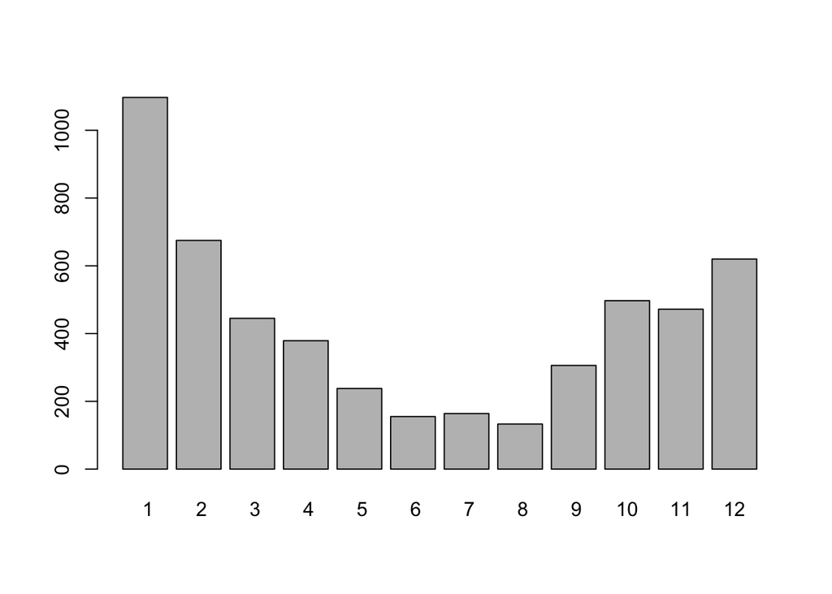

```r
FINALdta$WeekDate <- as.Date(as.character(FINALdta$WeekDate))
# getting rid of unwanted variables: dengue serotype and other date variables
model.data <- FINALdta[c("WeekDate", "Total", "Estimated_population", "MinAT","MaxAT", "Precip", "TAvg", "SOI", "NINO4", "NINO3.4", "ENSO")]

barplot(tapply(FINALdta$Total, format(FINALdta$Month), FUN=sum)) #checking out how we want to split up the data. Traditional Jan-March will work since it is splitting up dengue peak season
```

```r
# Checking out any N/A, using my favorite is.na line of code to see where the NA's are in various weather data locations.
model.data  %>%
  summarise_all(list(~is.na(.)))%>%
  pivot_longer(everything(), names_to = "variables", values_to="missing") %>%
  count(variables, missing)
```

```
## # A tibble: 15 × 3
##    variables            missing     n
##    <chr>                <lgl>   <int>
##  1 ENSO                 FALSE     677
##  2 Estimated_population FALSE     677
##  3 MaxAT                FALSE     676
##  4 MaxAT                TRUE        1
##  5 MinAT                FALSE     676
##  6 MinAT                TRUE        1
##  7 NINO3.4              FALSE     677
##  8 NINO4                FALSE     677
##  9 Precip               FALSE     676
## 10 Precip               TRUE        1
## 11 SOI                  FALSE     677
## 12 TAvg                 FALSE     676
## 13 TAvg                 TRUE        1
## 14 Total                FALSE     677
## 15 WeekDate             FALSE     677
```

```r
## Only 4 found. Going to delete them because there are all on line 677
model.data <- model.data[-c(677), ]
```

### Splitting into quarterly data

As mentioned earlier, we are going to be changing this weekly time series data into quarterly.

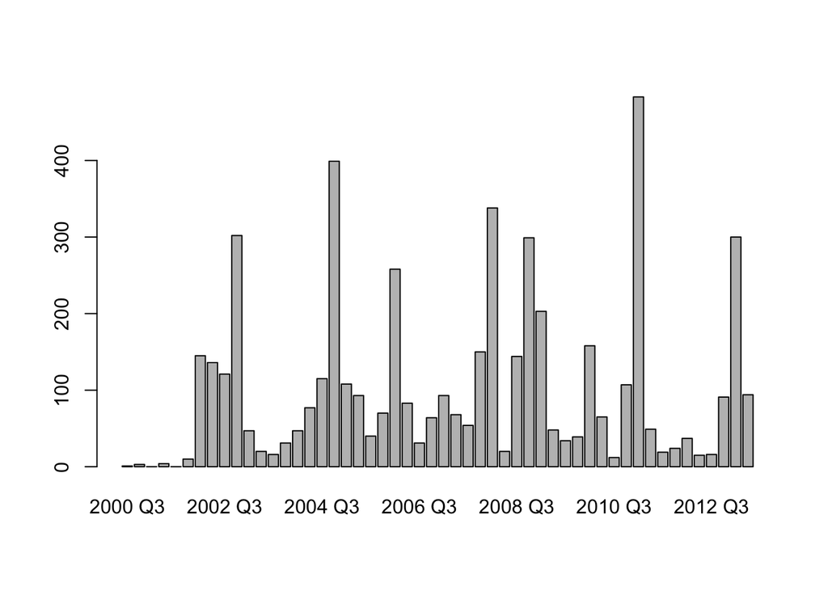

```r
model.data$quarter = as.yearqtr(model.data$WeekDate)
qdta <- model.data %>% group_by(quarter) %>% summarise(
    Total = sum(Total),
    Pop = mean(Estimated_population),
    MinAT = mean(MinAT),
    MaxAT = mean(MaxAT),
    Precip = mean(Precip),
    TAvg = mean(TAvg),
    SOI = mean(SOI),
    NINO4= mean(NINO4),
    NINO3.4= mean(NINO3.4),
    ENSO= sum(ENSO),) # Since it will be counted via quarter, this will in itself be a new function of ENSO month events/ quarter.
barplot(tapply(qdta$Total, format(qdta$quarter), FUN=sum))
```

```r
# Creating a correlation matrix
A1P1tbl  <- cor(qdta[, unlist(lapply(qdta, is.numeric))])
A1P1tbl
```

```
##               Total         Pop       MinAT       MaxAT      Precip
## Total    1.00000000  0.16710606  0.38737669 -0.12888454  0.26137054
## Pop      0.16710606  1.00000000  0.14196285 -0.15299071  0.36987499
## MinAT    0.38737669  0.14196285  1.00000000  0.05751045  0.66104474
## MaxAT   -0.12888454 -0.15299071  0.05751045  1.00000000 -0.43595644
## Precip   0.26137054  0.36987499  0.66104474 -0.43595644  1.00000000
## TAvg     0.06702418 -0.06642203  0.50971135  0.88823464 -0.07126086
## SOI      0.25154880  0.32073926  0.10057484 -0.04803444  0.19635075
## NINO4   -0.23415306 -0.32859206 -0.10669350  0.18664378 -0.31085954
## NINO3.4 -0.21932834 -0.16992790 -0.26518996 -0.19398643 -0.20169469
## ENSO    -0.16313910 -0.39296880 -0.09176472  0.11976386 -0.26033294
##                 TAvg          SOI      NINO4    NINO3.4        ENSO
## Total    0.067024183  0.251548796 -0.2341531 -0.2193283 -0.16313910
## Pop     -0.066422031  0.320739260 -0.3285921 -0.1699279 -0.39296880
## MinAT    0.509711346  0.100574838 -0.1066935 -0.2651900 -0.09176472
## MaxAT    0.888234639 -0.048034445  0.1866438 -0.1939864  0.11976386
## Precip  -0.071260863  0.196350753 -0.3108595 -0.2016947 -0.26033294
## TAvg     1.000000000  0.004922476  0.1117160 -0.2892101  0.06098111
## SOI      0.004922476  1.000000000 -0.8898684 -0.8202304 -0.80166581
## NINO4    0.111716037 -0.889868350  1.0000000  0.8551587  0.74411276
## NINO3.4 -0.289210051 -0.820230374  0.8551587  1.0000000  0.70355851
## ENSO     0.060981108 -0.801665808  0.7441128  0.7035585  1.00000000
```

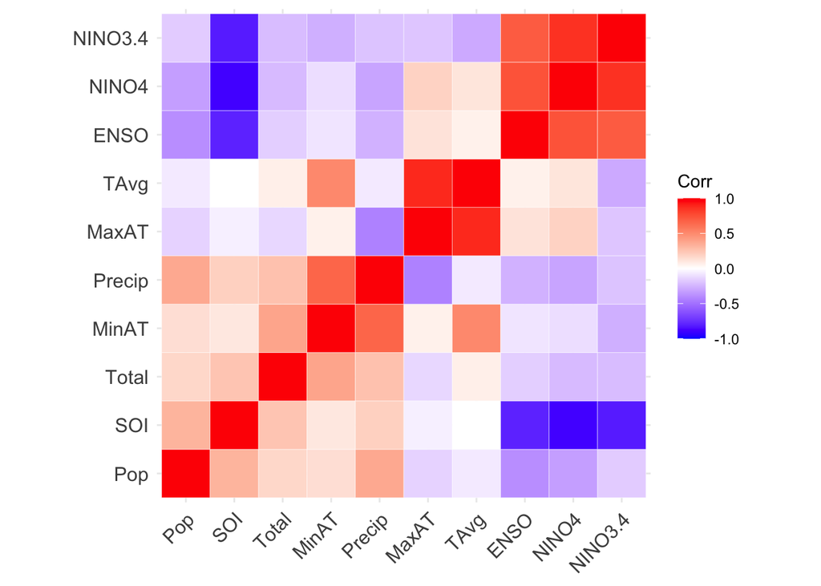

```r
saveRDS(A1P1tbl, file = here("results","analysisfigures", "A1P1tbl.rds"))

# graphing correlation matrix
A1P1 <- ggcorrplot(A1P1tbl, hc.order = TRUE, outline.col = "white")
A1P1
```

```r
ggsave(filename = here("results", "analysisfigures", "A1P1.png"), plot = A1P1 )
# as expected, there is a correlation between weather variables. Keeping SOI values in mind
```

Setting data into time series form

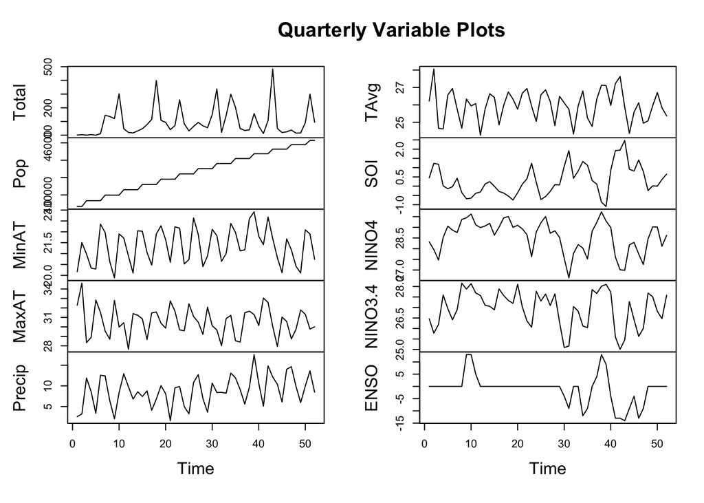

```r
q.ts.dta  <- ts(qdta, start = c(2000), frequency = 4) # set to 4 to start the quarter
A1P2 <- plot.ts(qdta[,c(2:11)], main = "Quarterly Variable Plots") +  theme_minimal()  #Can only plot 10 variables with plot.ts, so I am taking out quarter
```

```r
png(file = "results/analysisfigures/A1P2.png", width=600, height=400)
```

Checking to see if data is normally distributed

```r
which(is.na(model.data))
```

```
## integer(0)
```

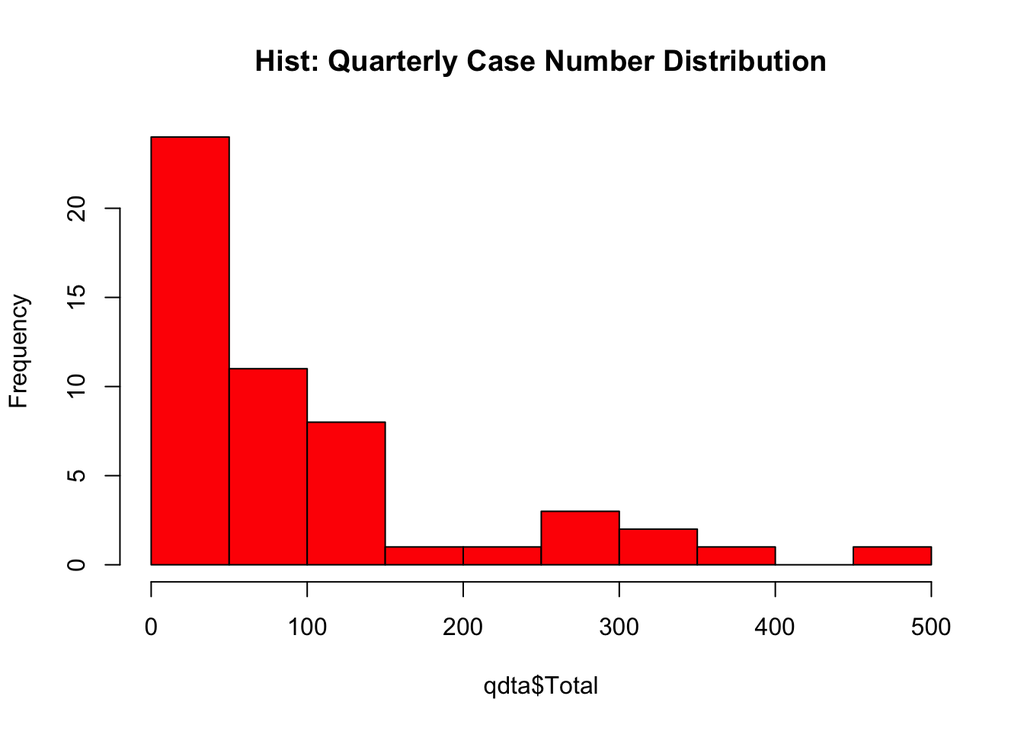

```r
A1P3 <- hist(qdta$Total,col='red', main = "Hist: Quarterly Case Number Distribution")
```

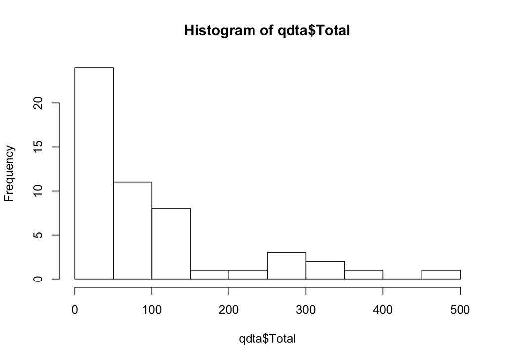

```r
plot(A1P3)
```

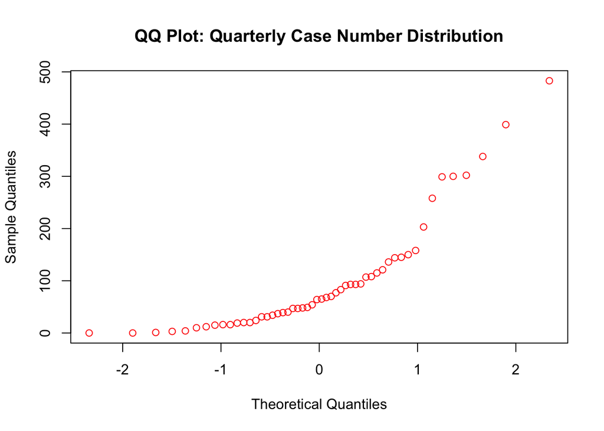

```r
A1P4 <- qqnorm(qdta$Total,col='red', main = "QQ Plot: Quarterly Case Number Distribution")
```

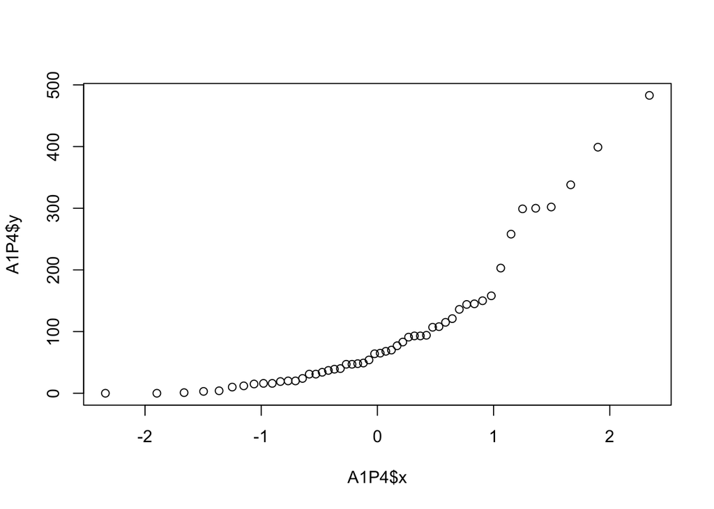

```r
plot(A1P4)
```

```r
# No, Dengue data is not normally distributed. Over dispersion
png(filename = here("results", "analysisfigures", "A1P3.png"))
png(filename = here("results", "analysisfigures", "A1P4.png"))

logqdta <- log(qdta$Total)
hist(logqdta, col='red', main = "Hist: Quarterly Case Number Distribution")
```

[output not shown]

Because data is overdispersed, going to try out both a Negative binomial regression and a Poisson regression with logged and non logged outcome

### Data splitting

```r
train.dta<- qdta %>%filter(quarter < 2010)
test.dta<- qdta %>%filter(quarter >= 2010)
```

[output not shown]

## Multiple Linear Regression with PCA

Will be applying principal component analysis to address the multi-colinearity that exists between the variables. Source: https://juliasilge.com/blog/cocktail-recipes-umap/ https://rdrr.io/github/tidymodels/learntidymodels/f/inst/tutorials/pca_recipes/pca_recipes.Rmd

```r
# creating model type
lm.mod <- linear_reg() %>%
            set_engine('lm') %>%
            set_mode('regression')

# create recipe
mlr.rec <- recipe(Total ~ Pop + MinAT + MaxAT + Precip + TAvg + SOI + NINO4 + NINO3.4 + ENSO,
  data = train.dta) %>%
  step_dummy(all_nominal_predictors()) %>%
  step_normalize(SOI, ENSO) %>%
  step_center(all_predictors()) %>%
  step_pca(all_predictors()) # principal component analysis
```